# Epistemology and Beliefs

Edward Hill

13-12-2021

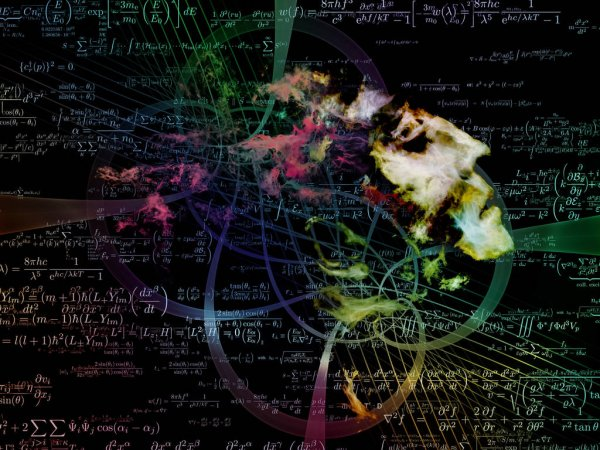

Epistemology and beliefs

**Abstract** There are at least twelve major virtues of good theories: evidential accuracy, causal adequacy, explanatory depth, internal consistency, internal coherence, universal coherence, beauty, simplicity, unification, durability, fruitfulness, and applicability. These virtues are best classified into four classes: evidential, coherential, aesthetic, and diachronic. Each virtue class contains at least three virtues that sequentially follow a repeating pattern of progressive disclosure and expansion. Systematizing the theoretical virtues in this manner clarifies each virtue and suggests how they might have a coordinated and cumulative role in theory formation and evaluation across the disciplines—with allowance for discipline specific modification. An informal and flexible logic of theory choice is in the making here. Evidential accuracy (empirical fit), according to my systematization, is not a largely isolated trait of good theories, as some (realists and antirealists) have made it out to be. Rather, it bears multifaceted relationships, constituting significant epistemic entanglements, with other theoretical virtues.

**Keywords** Theoretical virtues·Inference to the best explanation·Epistemic value·Aesthetics·Prediction·Science–technology relations

# 1 Introduction

Theoretical virtues are the traits of a theory that show it is probably true or worth accepting. Although the identification, characterization, classification, and epistemic standing of theory virtues are debated by philosophers and by participants in specific theoretical disputes, many scholars agree that these virtues help us to infer which rival theory is the best explanation Lipton (2004). Analysis of widely accepted theories,especially in the natural sciences, can help us to more skillfully use these tools in all disciplines. I offer a new systematization of the theoretical virtues to deepen our understanding of them.The most widely accepted theories across the academic disciplines usually exhibit many of the same theoretical virtues listed below. Each virtue class contains at least three virtues that sequentially follow a repeating pattern of progressive disclosure and expansion. This pattern, and other systematic features, will become apparent as we explore the theoretical virtues.

Evidential virtues

1. *Evidential accuracy*: A theory (T) fits the empirical evidence well (regardless ofcausal claims).
2. *Causal adequacy*: T’s causal factors plausibly produce the effects (evidence) in need of explanation.
3. *Explanatory depth*: T excels in causal history depth or in other depth measures suchas the range of counterfactual questions that its law-like generalizations answer regarding the item being explained.

Coherential virtues

4. *Internal consistency*: T’s components are not contradictory.
5. *Internal coherence*: T’s components are coordinated into an intuitively plausible whole; T lacks ad hoc hypotheses—theoretical components merely tacked on to solve isolated problems.
6. *Universal coherence*: T sits well with (or is not obviously contrary to) other war-ranted beliefs.Aesthetic virtues
7. *Beauty*: T evokes aesthetic pleasure in properly functioning and sufficiently informed persons.
8. *Simplicity*: T explains the same facts as rivals, but with less theoretical content.
9. *Unification*: T explains more kinds of facts than rivals with the same amount of theoretical content.

Diachronic virtues

10. *Durability*: T has survived testing by successful prediction or plausible accommodation of new data.
11. *Fruitfulness*: T has generated additional discovery by means such as successful novel prediction, unification,2and non ad hoc theoretical elaboration.
12. *Applicability*: T has guided strategic action or control, such as in science-based technology

I will show how this theoretical virtue taxonomy is more illuminating than others(e.g., it helped me identify the virtue of applicability, which is absent from earlier lists and taxonomies). Previous attempts at understanding and classifying the theoretical virtues would have been more successful had they attended to all of these major virtues and their relations. After a glimpse at early attempts to understand and classify the theoretical virtues, we will explore each of the virtues and their taxonomic relations.

## 2 **Early attempts to understand and systematize the theoretical virtues**

In response to critics who charged him with undermining science’s rationality, Kuhn wrote:

> I have implicitly assumed that, whatever their initial source, the criteria or values deployed in theory-choice are fixed once and for all, unaffected by their transition from one theory to another. Roughly speaking, but only roughly speaking, I take that to be the case. If the list of relevant values be kept short … and if their specification be left vague, then such values … are permanent attributes of science Kuhn (1977), p. 335.

Kuhn listed five such permanent values (theoretical virtues) operative in theory choice: **accuracy**, **consistency**, **scope** (unification), **simplicity**, and **fruitfulness** (p. 332). He persisted in this understanding during his final years of work, affirming that the theoretical virtues are “necessarily permanent, for abandoning them would be abandoning science” Kuhn (1993), p. 338. Neither Kuhn, nor most others contributing to this topic,have proposed a classification system that indicates how the different theoretical virtues relate to each other.

> Sometimes epistemic values are regarded as a subset of cognitive values andidentified with values such as empirical adequacy and internal consistency that directly bear on the veracity of a scientific theory (Laudan (2004)). Values such as scope and explanatory power would then count as cognitive values that express scientific desiderata, but without properly epistemic implications. We have decided, however, to adopt a broader reading of “epistemic” where truthis not the only aim of scientific inquiry, but supplemented by providing causal mechanisms, finding natural laws, creating understanding, etc. In this sense, values such as scope or explanatory power contribute to achieving our epistemic goals. Neat distinctions between strictly truth-conducive and purely cognitive scientific values are hard to come by (see Douglas (2014) for a classification attempt).

# References

Douglas, H. 2014. “Pure science and the problem of progress.” *Studies in History and Philosophy of Science Part A* 46. https://doi.org/10.1016/j.shpsa.2014.02.001.

Kuhn, T S. 1977. “Objectivity, value judgment, and theory choice BT - The essential tension.” In, edited by T S Kuhn. Chicago: University of Chicago.

———. 1993. “Afterwords BT - World changes: Thomas Kuhn and the nature of science.” In, edited by P Horwich. Cambridge: MIT Press.

Laudan, L. 1984. *Science and values*. Berkeley: University of California Press.

———. 2004. “The epistemic, the cognitive, and the social BT - Science, values, and objectivity.” In, edited by P K Machamer and G Wolters. Pittsburgh: University of Pittsburgh Press. https://doi.org/10.2307/j.ctt5vkg7t.5.

Lipton, P. 2004. *Inference to the best explanation*. London: Routledge.